# Merging the datasets with tidyverse

Aki Matsuo

8/11/2020

## Day 2

We are going to use the covid 19 dataset along with the other two datasets (in “data/” folder).

- JHU dataset
- Country level demographic data
- Presidential voting in 2016

All datasets are coming from Kaggle.

- https://www.kaggle.com/headsortails/covid19-us-county-jhu-data-demographics
- https://www.kaggle.com/stevepalley/2016uspresidentialvotebycounty
- https://www.kaggle.com/muonneutrino/us-census-demographic-data

The task is

1. check the data completeness (e.g. make sure that all datasets have common list of counties)
2. merge the datasets
3. check whether there are any relations between covid and any demographic/political indexes

## Packages

```r
library(tidyverse)
```

## Read three data files

```r
data_covid <- read_csv("../data/covid_us_county.csv.gz", guess_max = 1e5)
data_demo <- read_csv("../data/acs2017_county_data.csv")
data_pres <- read_csv("../data/pres16results.csv")
```

## Check the validity of the data

### How the data look like

```r
head(data_covid)
```

```
## # A tibble: 6 x 9
##    fips county state            lat  long date       cases state_code deaths
##   <dbl> <chr>  <chr>          <dbl> <dbl> <date>     <dbl> <chr>       <dbl>
## 1    60 <NA>   American Samoa -14.3 -170. 2020-01-22     0 <NA>            0
## 2    60 <NA>   American Samoa -14.3 -170. 2020-01-23     0 <NA>            0
## 3    60 <NA>   American Samoa -14.3 -170. 2020-01-24     0 <NA>            0
## 4    60 <NA>   American Samoa -14.3 -170. 2020-01-25     0 <NA>            0
## 5    60 <NA>   American Samoa -14.3 -170. 2020-01-26     0 <NA>            0
## 6    60 <NA>   American Samoa -14.3 -170. 2020-01-27     0 <NA>            0
```

```r
head(data_demo)
```

```
## # A tibble: 6 x 37
##   CountyId State County TotalPop   Men  Women Hispanic White Black Native Asian
##      <dbl> <chr> <chr>     <dbl> <dbl>  <dbl>    <dbl> <dbl> <dbl>  <dbl> <dbl>
## 1     1001 Alab~ Autau~    55036 26899  28137      2.7  75.4  18.9    0.3   0.9
## 2     1003 Alab~ Baldw~   203360 99527 103833      4.4  83.1   9.5    0.8   0.7
## 3     1005 Alab~ Barbo~    26201 13976  12225      4.2  45.7  47.8    0.2   0.6
## 4     1007 Alab~ Bibb ~    22580 12251  10329      2.4  74.6  22      0.4   0
## 5     1009 Alab~ Bloun~    57667 28490  29177      9    87.4   1.5    0.3   0.1
## 6     1011 Alab~ Bullo~    10478  5616   4862      0.3  21.6  75.6    1     0.7
## # ... with 26 more variables: Pacific <dbl>, VotingAgeCitizen <dbl>,
## #   Income <dbl>, IncomeErr <dbl>, IncomePerCap <dbl>, IncomePerCapErr <dbl>,
## #   Poverty <dbl>, ChildPoverty <dbl>, Professional <dbl>, Service <dbl>,
## #   Office <dbl>, Construction <dbl>, Production <dbl>, Drive <dbl>,
## #   Carpool <dbl>, Transit <dbl>, Walk <dbl>, OtherTransp <dbl>,
## #   WorkAtHome <dbl>, MeanCommute <dbl>, Employed <dbl>, PrivateWork <dbl>,
## #   PublicWork <dbl>, SelfEmployed <dbl>, FamilyWork <dbl>, Unemployment <dbl>
```

```r
head(data_pres)
```

```
## # A tibble: 6 x 9
##   county fips  cand        st    pct_report   votes total_votes     pct lead
##   <chr>  <chr> <chr>       <chr>      <dbl>   <dbl>       <dbl>   <dbl> <chr>
## 1 <NA>   US    Donald Tru~ US         0.995  6.04e7   127592176 0.473   Donald ~
## 2 <NA>   US    Hillary Cl~ US         0.995  6.10e7   127592176 0.478   Donald ~
## 3 <NA>   US    Gary Johns~ US         0.995  4.16e6   127592176 0.0326  Donald ~
## 4 <NA>   US    Jill Stein  US         0.995  1.26e6   127592176 0.00984 Donald ~
## 5 <NA>   US    Evan McMul~ US         0.995  4.52e5   127592176 0.00354 Donald ~
## 6 <NA>   US    Darrell Ca~ US         0.995  1.81e5   127592176 0.00142 Donald ~
```

- renaming is necessary for `data_demo`
- need to remove uncessary entries in fips of `data_pres`

```r
data_demo <- data_demo %>%
  rename(fips = CountyId)

data_covid <- data_covid %>%
  filter(!is.na(county))

data_pres <- data_pres %>%
  mutate(fips = as.numeric(fips)) %>%
  filter(!is.na(fips))
```

### How many rows in each df?

```r
nrow(data_covid)
```

```
## [1] 666800
```

```r
nrow(data_demo)
```

```
## [1] 3220
```

```r
nrow(data_pres)
```

```
## [1] 18141
```

### Number of counties in each data frame

- Which variable would you use to check?
- How many unique counties in each data set?
- Do they match? (if not does this seem problematic)?

```r
data_covid$fips %>% unique %>% length
```

```
## [1] 3325
```

```r
data_demo$fips %>% unique %>% length
```

```
## [1] 3220
```

```r
data_pres$fips %>% unique %>% length
```

```
## [1] 3237
```

```r
unique(data_demo$fips) %in% unique(data_covid$fips) %>% table()
```

```
## .
## TRUE
## 3220
```

```r
unique(data_demo$fips) %in% unique(data_pres$fips) %>% table()
```

```
## .
## FALSE  TRUE
##     1  3219
```

```r
data_covid_check <-
  data_covid %>% group_by(fips) %>% slice(1)

data_covid_check %>%
  anti_join(data_demo, by = "fips")
```

```
## # A tibble: 105 x 9
## # Groups:   fips [105]
##     fips county     state         lat  long date       cases state_code deaths
##    <dbl> <chr>      <chr>       <dbl> <dbl> <date>     <dbl> <chr>       <dbl>
##  1 72888 Out of PR  Puerto Rico     0     0 2020-01-22     0 <NA>            0
##  2 72999 Unassigned Puerto Rico     0     0 2020-01-22     0 <NA>            0
##  3 80001 Out of AL  Alabama         0     0 2020-01-22     0 AL              0
##  4 80002 Out of AK  Alaska          0     0 2020-01-22     0 AK              0
##  5 80004 Out of AZ  Arizona         0     0 2020-01-22     0 AZ              0
##  6 80005 Out of AR  Arkansas        0     0 2020-01-22     0 AR              0
##  7 80006 Out of CA  California      0     0 2020-01-22     0 CA              0
##  8 80008 Out of CO  Colorado        0     0 2020-01-22     0 CO              0
##  9 80009 Out of CT  Connecticut     0     0 2020-01-22     0 CT              0
## 10 80010 Out of DE  Delaware        0     0 2020-01-22     0 DE              0
## # ... with 95 more rows
```

```r
data_covid_check %>%
  anti_join(data_pres, by = "fips")
```

```
## # A tibble: 106 x 9
## # Groups:   fips [106]
##     fips county     state         lat  long date       cases state_code deaths
##    <dbl> <chr>      <chr>       <dbl> <dbl> <date>     <dbl> <chr>       <dbl>
##  1  2158 Kusilvak   Alaska       62.2 -163. 2020-01-22     0 AK              0
##  2 72888 Out of PR  Puerto Rico   0      0  2020-01-22     0 <NA>            0
##  3 72999 Unassigned Puerto Rico   0      0  2020-01-22     0 <NA>            0
##  4 80001 Out of AL  Alabama       0      0  2020-01-22     0 AL              0
##  5 80002 Out of AK  Alaska        0      0  2020-01-22     0 AK              0
##  6 80004 Out of AZ  Arizona       0      0  2020-01-22     0 AZ              0
##  7 80005 Out of AR  Arkansas      0      0  2020-01-22     0 AR              0
##  8 80006 Out of CA  California    0      0  2020-01-22     0 CA              0
##  9 80008 Out of CO  Colorado      0      0  2020-01-22     0 CO              0
## 10 80009 Out of CT  Connecticut   0      0  2020-01-22     0 CT              0
## # ... with 96 more rows
```

## Keep the necessary data

### Get the latest numbers cases

- From covid dataset, get the latest figures for each county

```r
data_covid_latest <- data_covid %>% group_by(fips) %>%
  arrange(desc(date)) %>% slice(1)
```

### Extract trump votes

presidential votes - Keep only trump vote rows

```r
data_trump <- data_pres %>%
  filter(cand == "Donald Trump")
```

## Merge the datasets

### Merging

- Now lets merge the data set
  1. latest covid data
  2. country demographics
  3. presidential votes

```r
data_merged <-
  data_covid_latest %>%
  inner_join(data_trump, by = "fips") %>%
  inner_join(data_demo, by = "fips")
```

```r
data_merged <- data_merged %>%
  mutate(cases_per1000 = cases / TotalPop) %>%
  mutate(deaths_per1000 = deaths / TotalPop)
```

## Using the merged datasets

- Get a correlation matrix or plot for the data
- `cor()`
- `pairs()`
- `GGally::ggpairs()`, correlation plot (I showed in day 4 lecture)

```r
data_merged %>%
  ungroup() %>%
  select(deaths_per1000, cases_per1000, Hispanic, Black, IncomePerCap, Unemployment) %>% cor()
```

```
##                deaths_per1000 cases_per1000    Hispanic      Black IncomePerCap
## deaths_per1000     1.00000000     0.5740642  0.10961882  0.3837830   0.02094092
## cases_per1000      0.57406422     1.0000000  0.25521930  0.4788724  -0.16595408
## Hispanic           0.10961882     0.2552193  1.00000000 -0.1153092  -0.05851138
## Black              0.38378300     0.4788724 -0.11530917  1.0000000  -0.25419640
## IncomePerCap       0.02094092    -0.1659541 -0.05851138 -0.2541964   1.00000000
## Unemployment       0.20003030     0.2726682  0.05589298  0.4485290  -0.47108254
##                Unemployment
## deaths_per1000   0.20003030
## cases_per1000    0.27266816
## Hispanic         0.05589298
## Black            0.44852903
## IncomePerCap    -0.47108254
## Unemployment     1.00000000
```

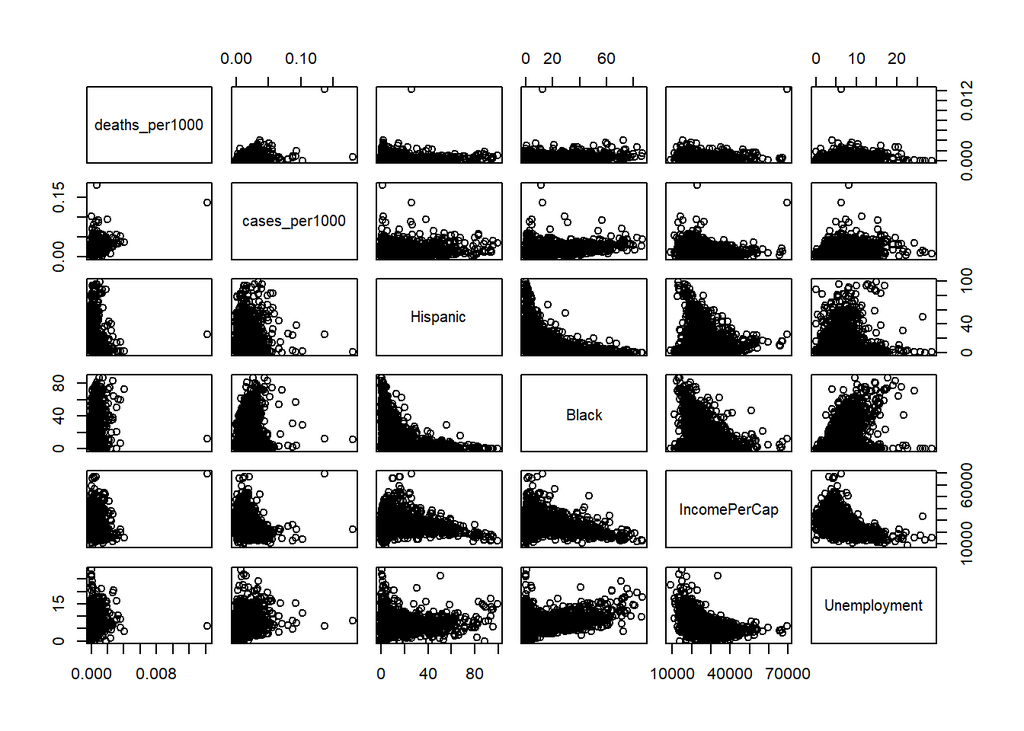

```r
data_merged %>%
  ungroup() %>%
  select(deaths_per1000, cases_per1000, Hispanic, Black, IncomePerCap, Unemployment) %>% pairs()
```

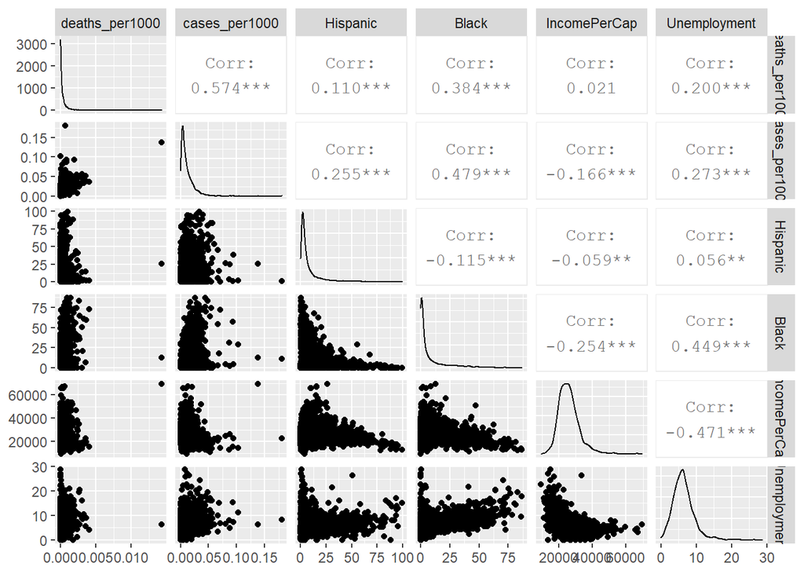

```r
data_merged %>%
  ungroup() %>%
  select(deaths_per1000, cases_per1000, Hispanic, Black, IncomePerCap, Unemployment) %>%
  GGally::ggpairs()
```

## Create a database

From the three datasets, let’s create a database

What we need to do is:

1. Remove some duplicated fiels
2. Create a database connection using `DBI` and `RSQlite`
3. Create tables from these datasets (using `dbWriteTable()`)
4. Disconnect from the db

### check the database fields

```r
data_demo <- data_demo %>% select(!c(State, County))
data_trump <- data_trump %>% select(!c(county, st, cand))
```

### Create database connection

```r
library(DBI)
file.remove("~/covid.sqlite")
```

```
## [1] TRUE
```

```r
db <- dbConnect(RSQLite::SQLite(), "~/covid.sqlite")
```

### Create/populate tables

```r
dbWriteTable(db, "covid", data_covid)
dbWriteTable(db, "demo", data_demo)
dbWriteTable(db, "trump", data_trump)
```

### Disconnect

```r
dbDisconnect(db)
```